# Zgony COVID

Kamil Pastor

8 listopada 2020

# Wprowadzenie

Na tej stronie będę regularnie aktualizował dane i analizy dotyczące śmiertelności w wybranych krajach Europy w ujęciu tygodniowym.

**Uwaga:** Dane spływają z różnymi opóźnieniami. Obserwacje za ostatnie tygodnie mogą być poddawane rewizjom, np. ze względu na fakt, że uwzględniają tylko część zgonów, które miały miejsce. Bardzo niska śmiertelność występująca w niektórych krajach na końcu szeregów jest więc najprawdopodobniej przykładem takich "niepełnych, wstępnych obserwacji" i w przyszłości będzie rewidowana w górę.

**Autor: Kamil Pastor. Po więcej grafik, wykresów i wizualizacji zapraszam do śledzenia mojego [konta na Twitterze](https://twitter.com/pastor_kamil).**

## Polska

Dane tygodniowe dla Polski. Ostatnie dane dotyczą tygodnia nr 44 (01 listopad 2020)

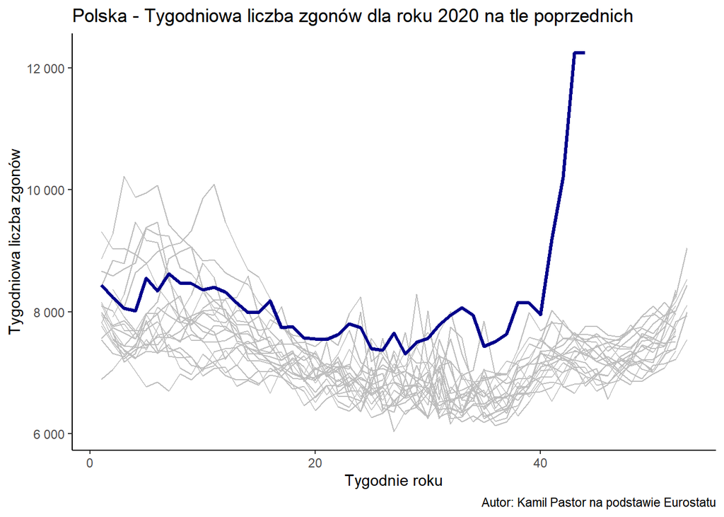

## Austria

Dane tygodniowe dla Austrii. Ostatnie dane dotyczą tygodnia nr 41 (11 październik 2020)

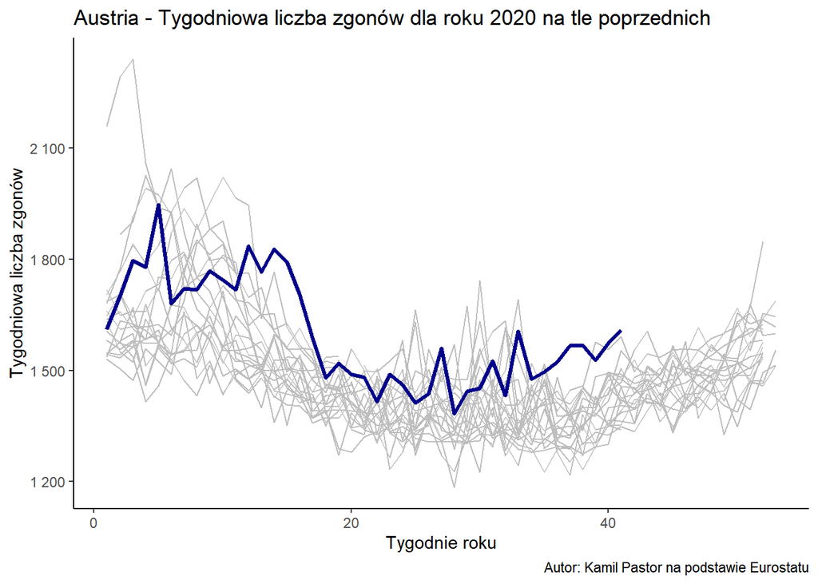

## Belgia

Dane tygodniowe dla Belgii. Ostatnie dane dotyczą tygodnia nr 43 (25 październik 2020)

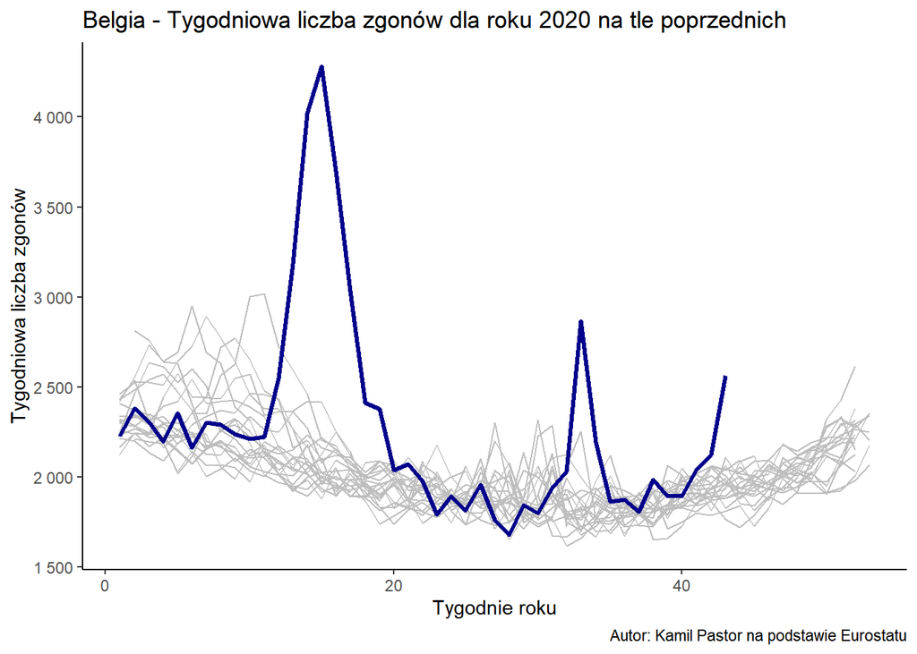

## Bułgaria

Dane tygodniowe dla Bułgarii. Ostatnie dane dotyczą tygodnia nr 43 (25 październik 2020)

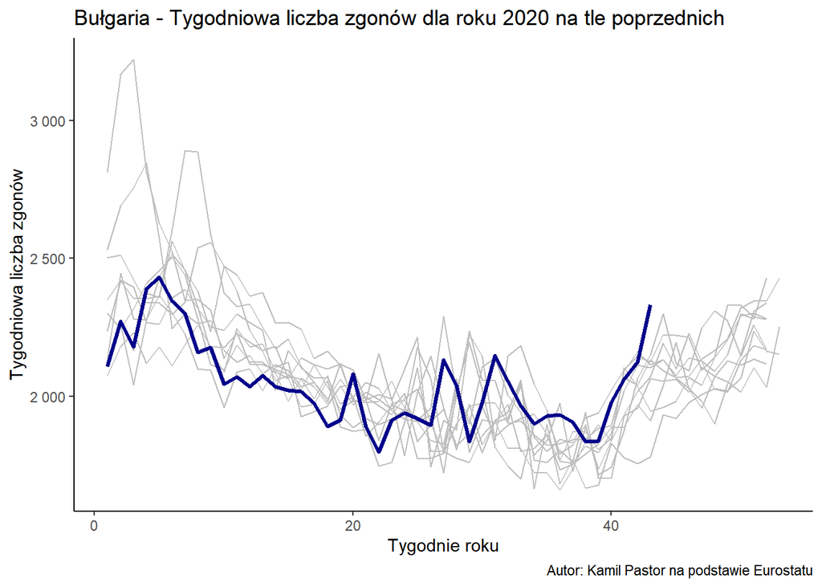

## Chorwacja

Dane tygodniowe dla Chorwacji. Ostatnie dane dotyczą tygodnia nr 35 (30 sierpień 2020)

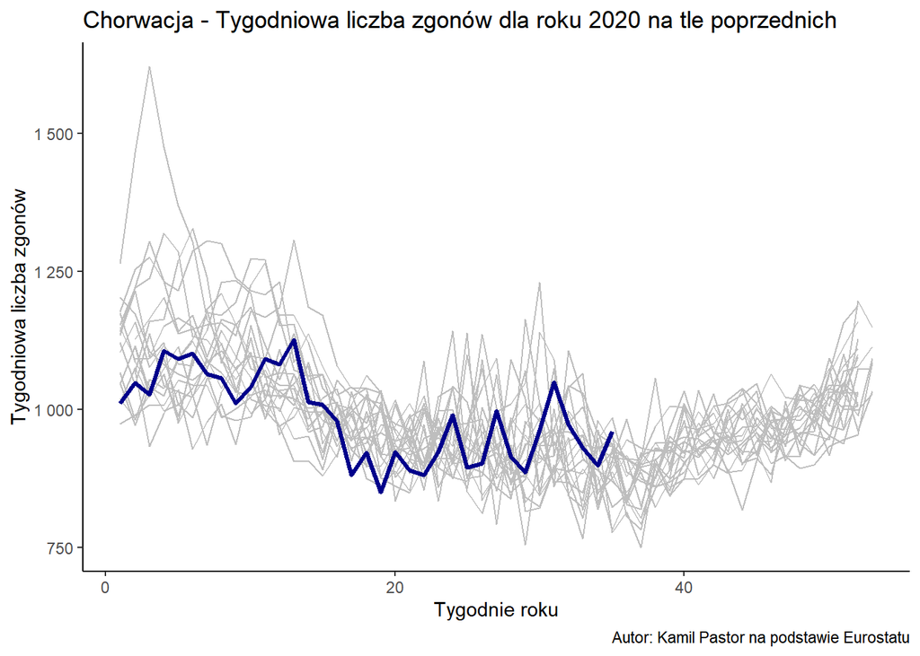

## Cypr

Dane tygodniowe dla Cypru. Ostatnie dane dotyczą tygodnia nr 40 (04 październik 2020)

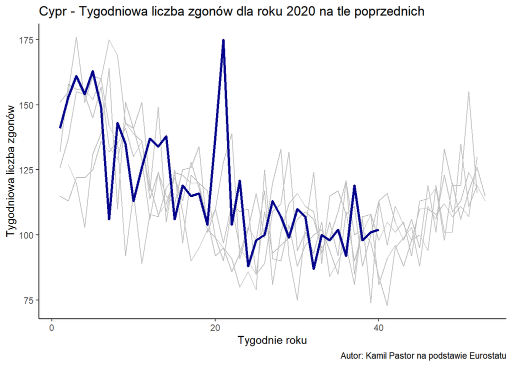

## Czechy

Dane tygodniowe dla Czech. Ostatnie dane dotyczą tygodnia nr 38 (20 wrzesień 2020)

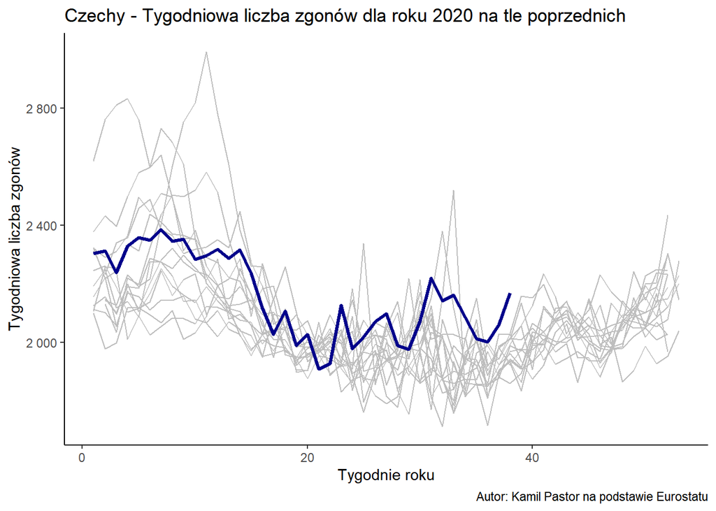

## Dania

Dane tygodniowe dla Danii. Ostatnie dane dotyczą tygodnia nr 44 (01 listopad 2020)

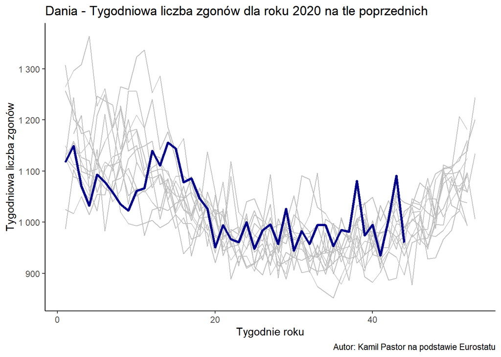

## Estonia

Dane tygodniowe dla Estonii. Ostatnie dane dotyczą tygodnia nr 44 (01 listopad 2020)

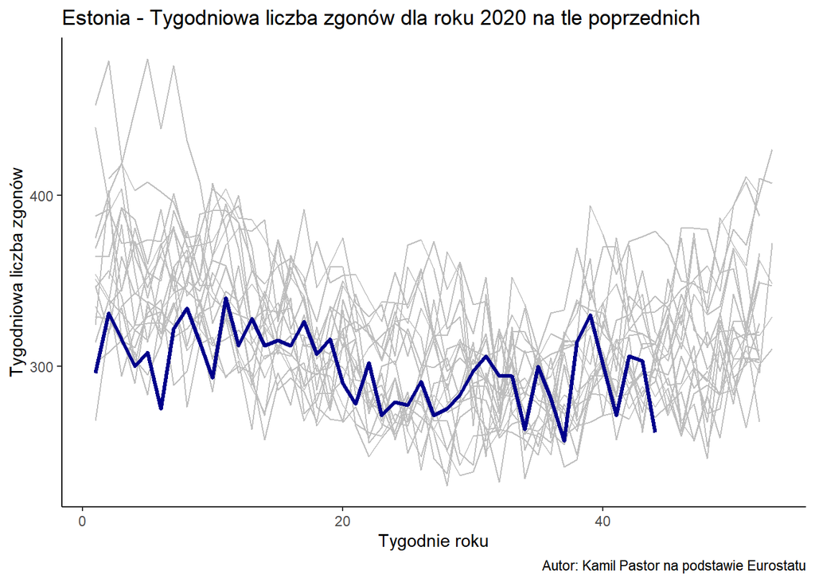

## Finlandia

Dane tygodniowe dla Finlandii. Ostatnie dane dotyczą tygodnia nr 43 (25 październik 2020)

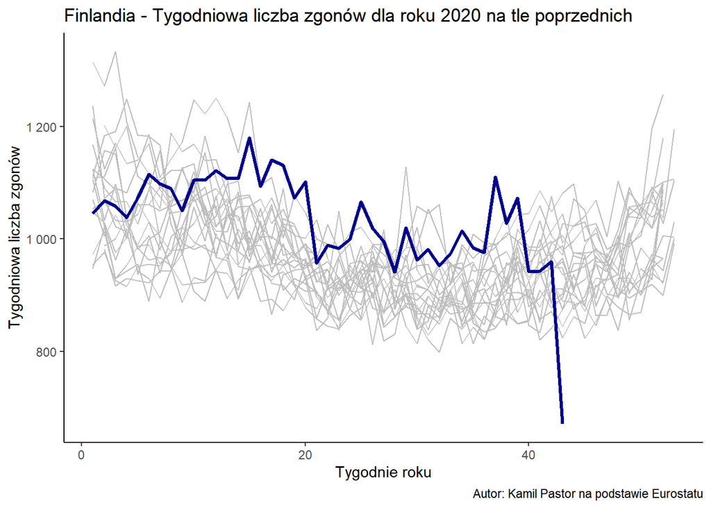

## Francja

Dane tygodniowe dla Francji. Ostatnie dane dotyczą tygodnia nr 42 (18 październik 2020)

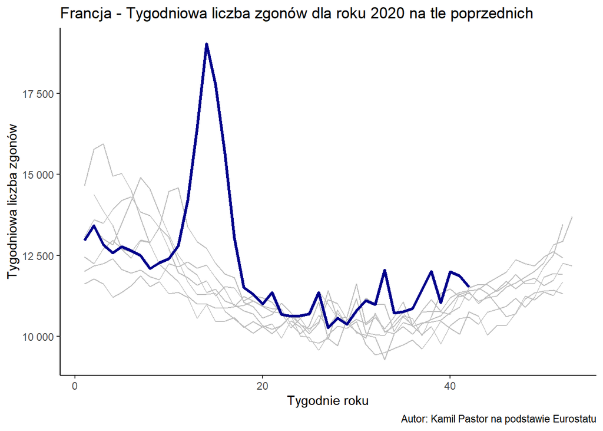

## Grecja

Dane tygodniowe dla Grecji. Ostatnie dane dotyczą tygodnia nr 30 (26 lipiec 2020)

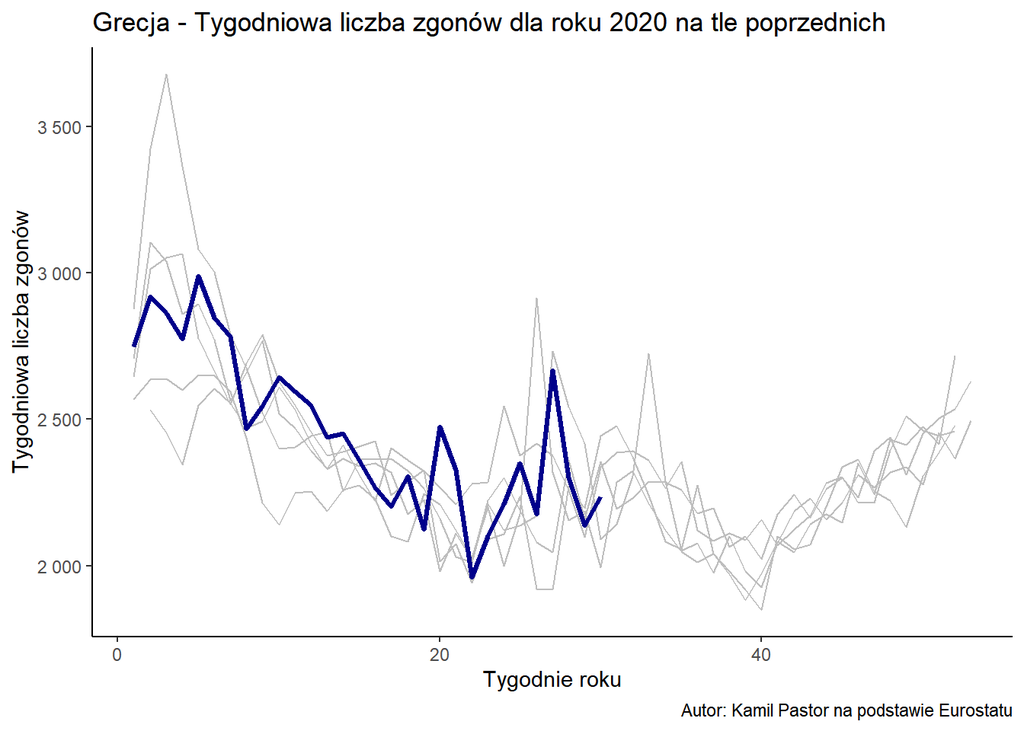

## Hiszpania

Dane tygodniowe dla Hiszpanii. Ostatnie dane dotyczą tygodnia nr 52 (29 grudzień 2019)

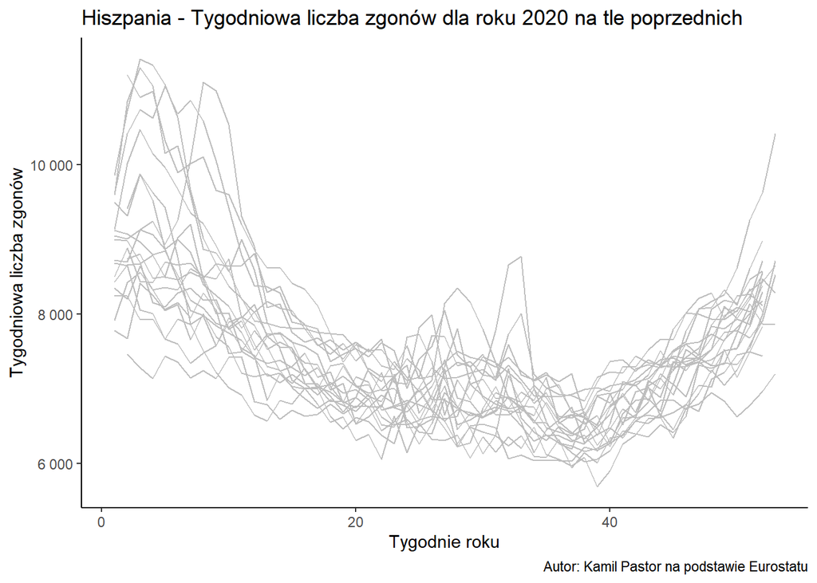

## Holandia

Dane tygodniowe dla Holandii. Ostatnie dane dotyczą tygodnia nr 42 (18 październik 2020)

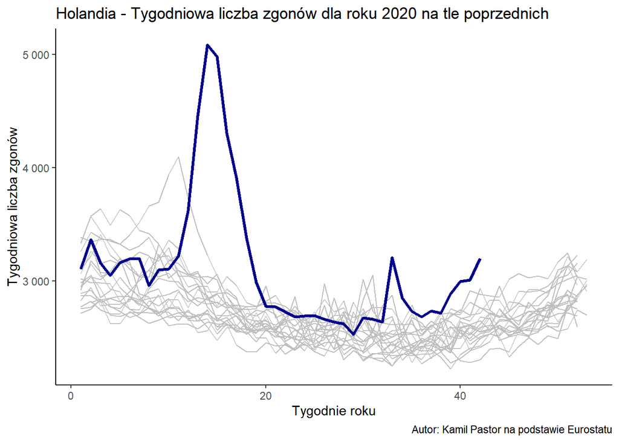

## Islandia

Dane tygodniowe dla Islandii. Ostatnie dane dotyczą tygodnia nr 41 (11 październik 2020)

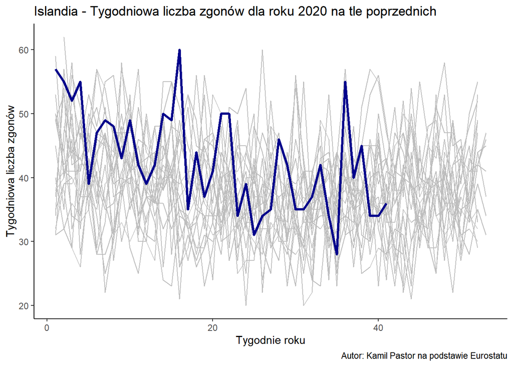

## Litwa

Dane tygodniowe dla Litwy. Ostatnie dane dotyczą tygodnia nr 43 (25 październik 2020)

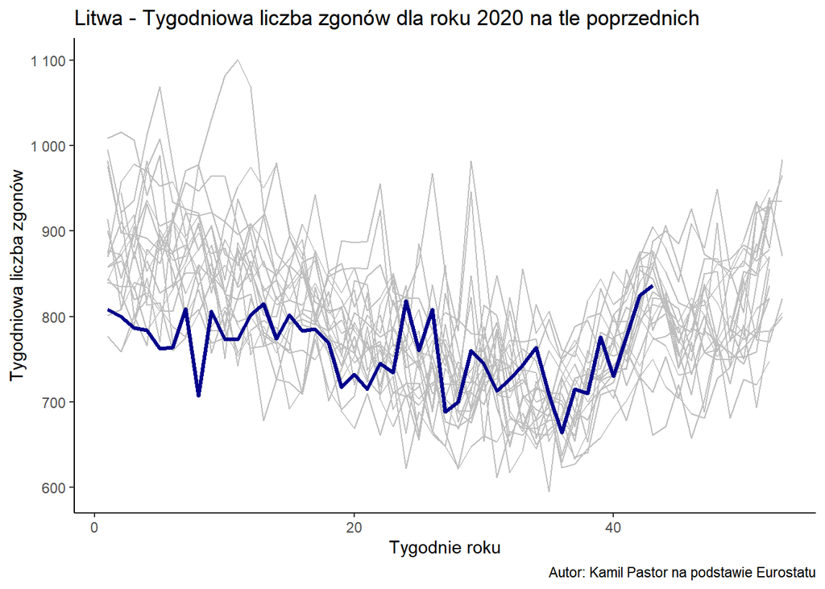

## Luksemburg

Dane tygodniowe dla Luksemburga. Ostatnie dane dotyczą tygodnia nr 39 (27 wrzesień 2020)

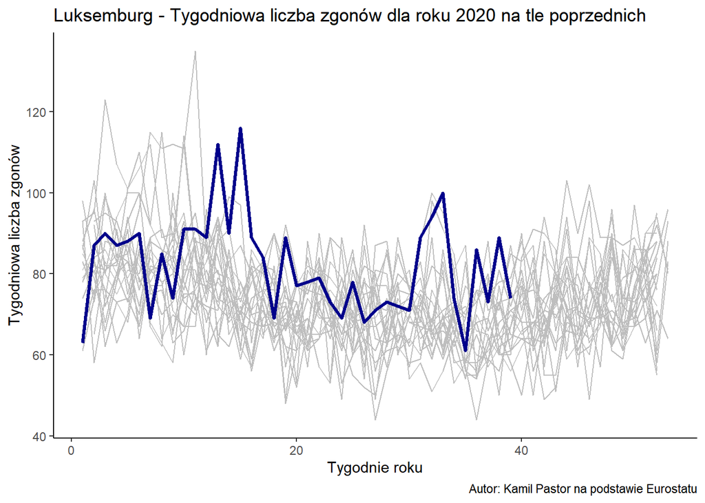

## Łotwa

Dane tygodniowe dla Łotwy. Ostatnie dane dotyczą tygodnia nr 44 (01 listopad 2020)

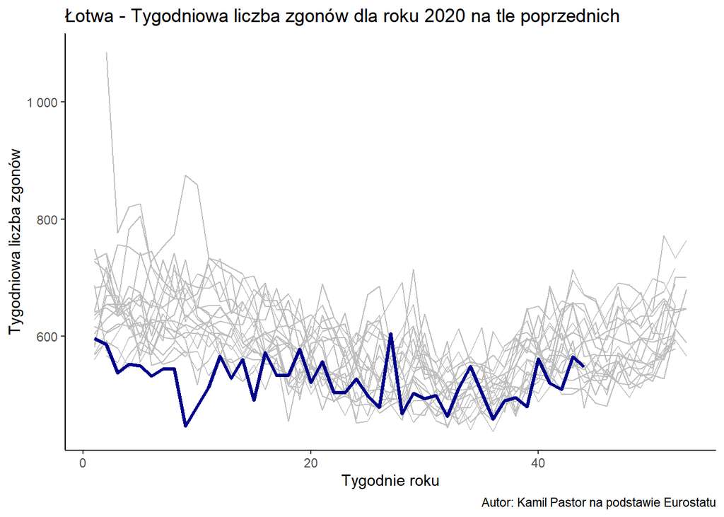

## Malta

Dane tygodniowe dla Malty. Ostatnie dane dotyczą tygodnia nr 39 (27 wrzesień 2020)

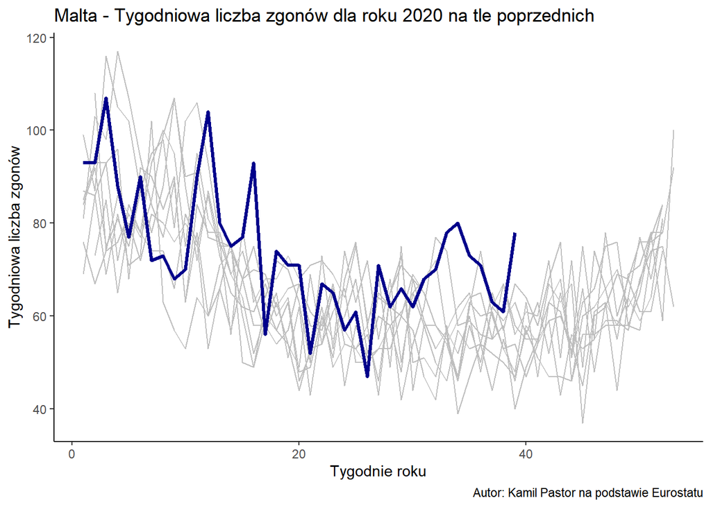

## Niemcy

Dane tygodniowe dla Niemiec. Ostatnie dane dotyczą tygodnia nr 41 (11 październik 2020)

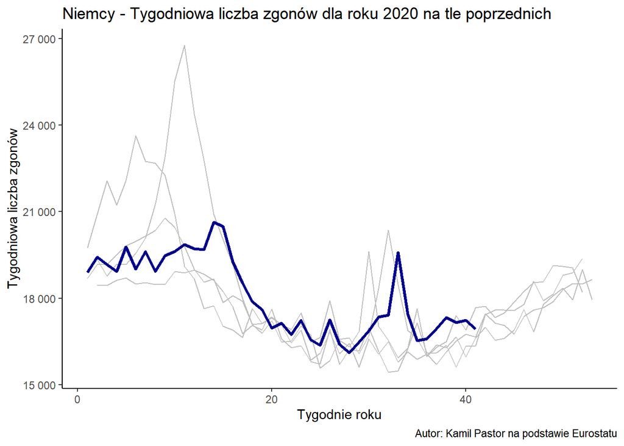

## Norwegia

Dane tygodniowe dla Norwegii. Ostatnie dane dotyczą tygodnia nr 43 (25 październik 2020)

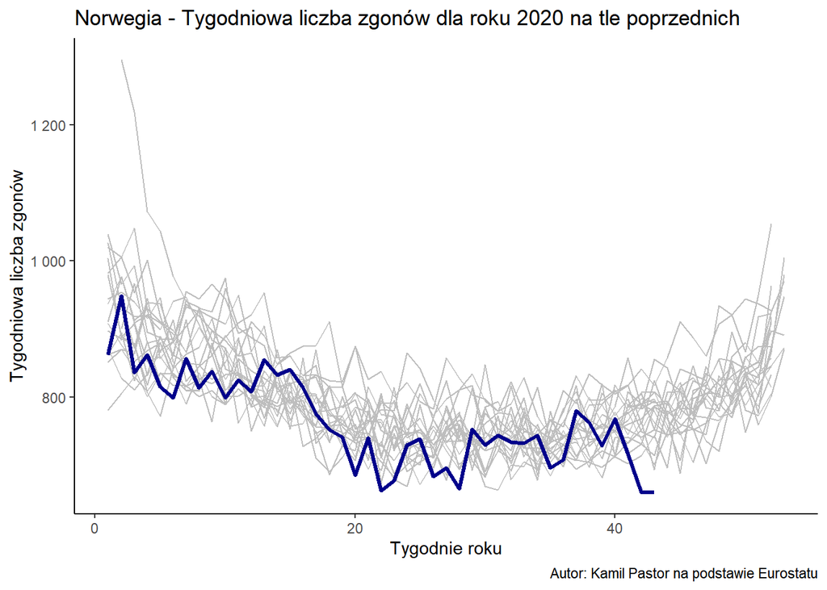

## Portugalia

Dane tygodniowe dla Portugalii. Ostatnie dane dotyczą tygodnia nr 43 (25 październik 2020)

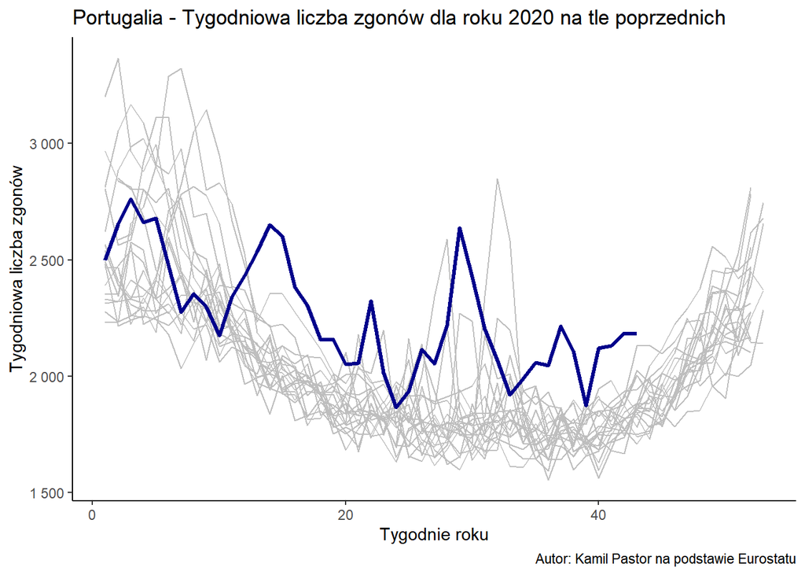

## Rumunia

Dane tygodniowe dla Rumunii. Ostatnie dane dotyczą tygodnia nr 35 (30 sierpień 2020)

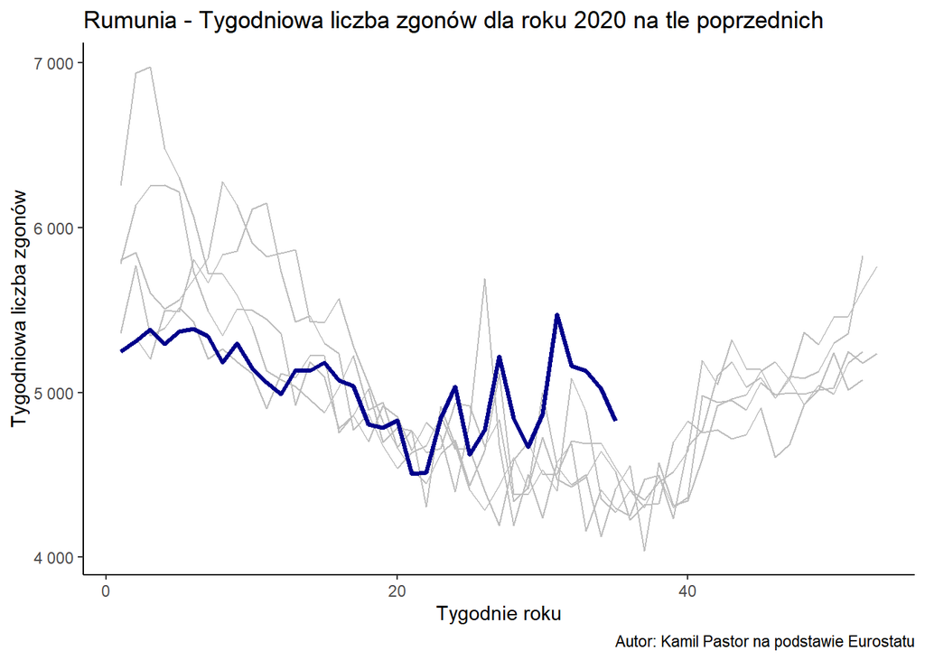

## Serbia

Dane tygodniowe dla Serbii. Ostatnie dane dotyczą tygodnia nr 39 (27 wrzesień 2020)

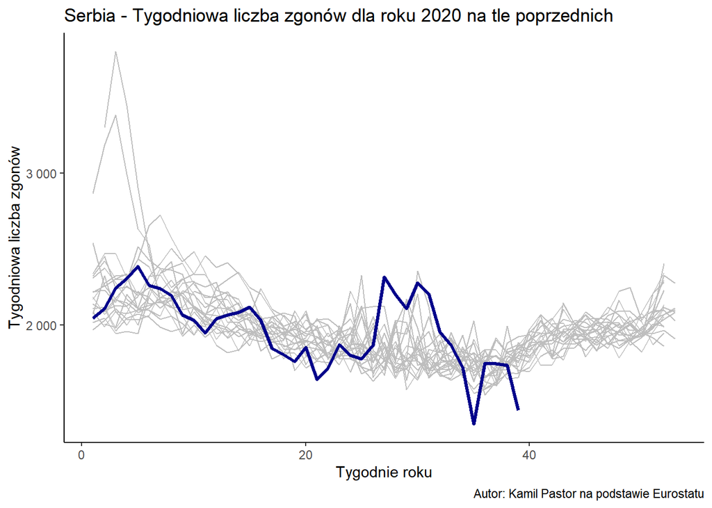

## Słowacja

Dane tygodniowe dla Słowacji. Ostatnie dane dotyczą tygodnia nr 39 (27 wrzesień 2020)

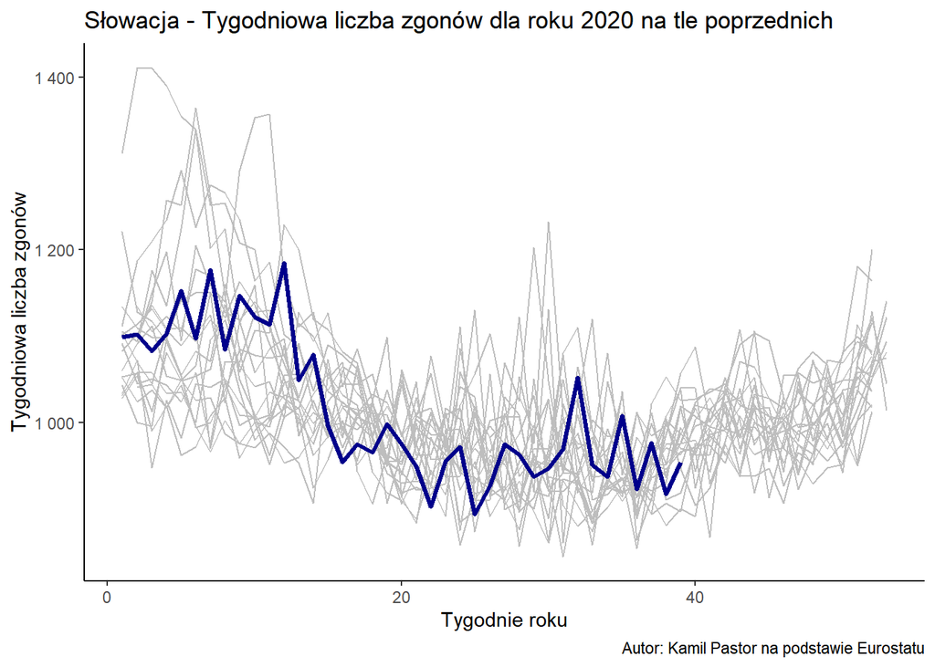

## Słowenia

Dane tygodniowe dla Słowenii. Ostatnie dane dotyczą tygodnia nr 39 (27 wrzesień 2020)

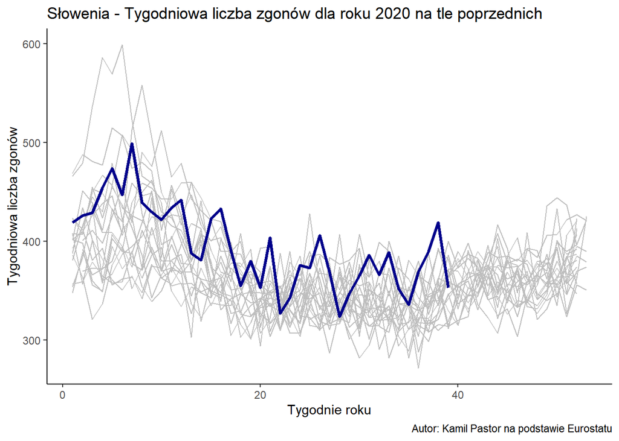

## Szwajcaria

[figure not shown]

## Szwecja

Dane tygodniowe dla Szwecji. Ostatnie dane dotyczą tygodnia nr 43 (25 październik 2020)

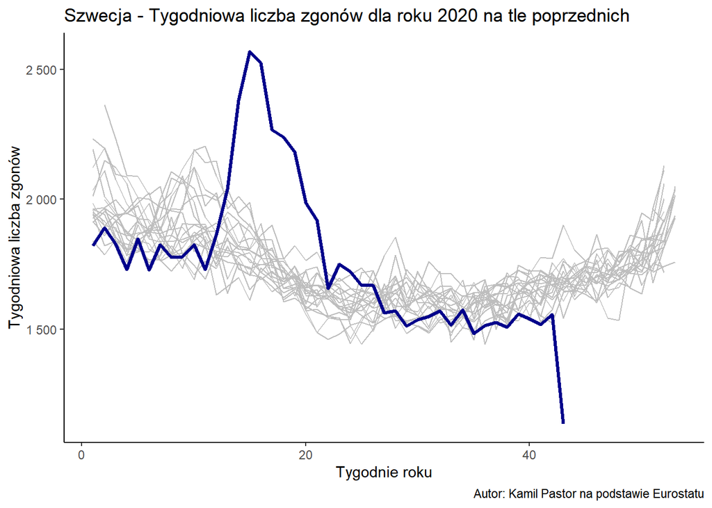

## Węgry

Dane tygodniowe dla Węgier. Ostatnie dane dotyczą tygodnia nr 40 (04 październik 2020)

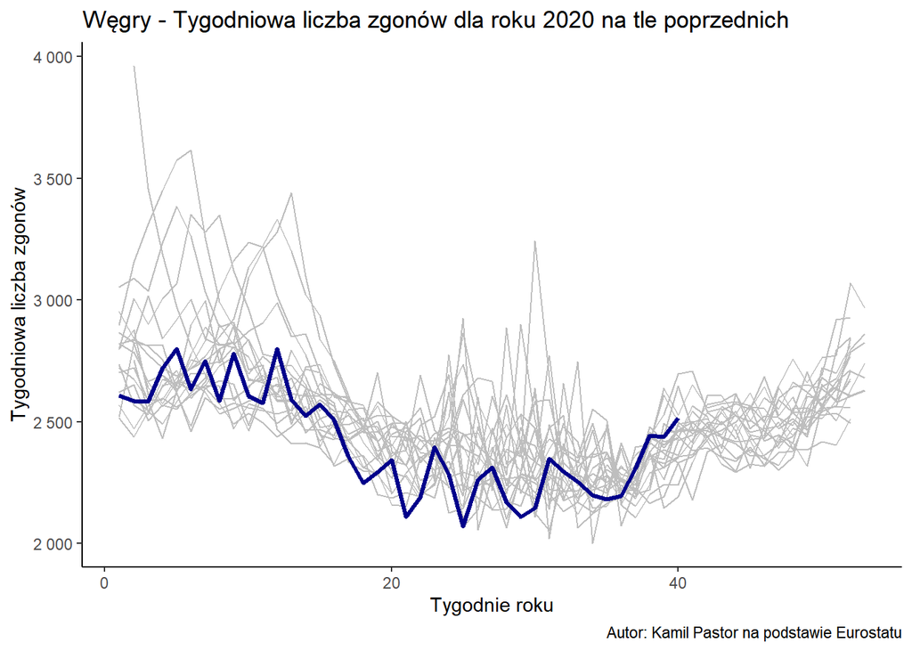

## Wielka Brytania

Dane tygodniowe dla Wielkiej Brytanii. Ostatnie dane dotyczą tygodnia nr 43 (25 październik 2020)

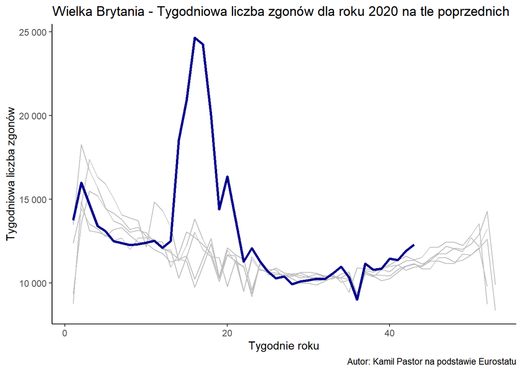

## Włochy

Dane tygodniowe dla Włoch. Ostatnie dane dotyczą tygodnia nr 35 (30 sierpień 2020)

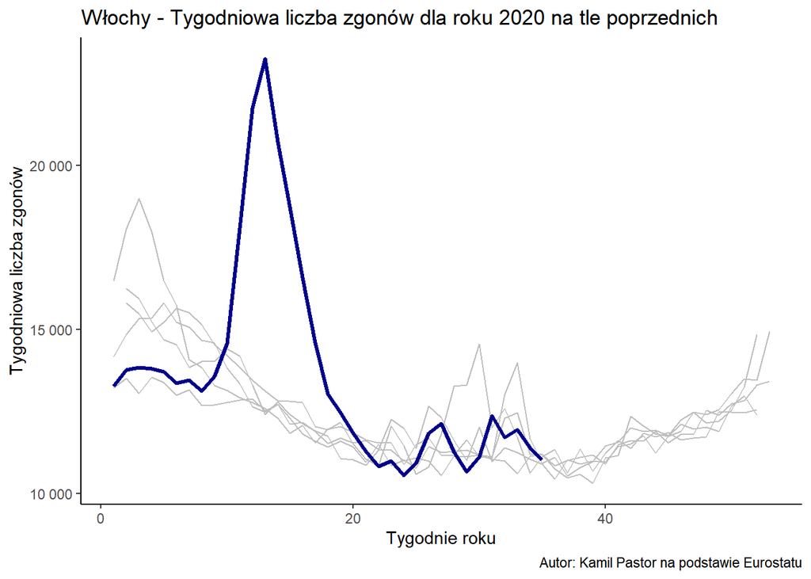